# Weather Information Preferences in the United States

Summary Report for the Pacific Region

Author: Dave Holtschlag

Saturday, March 17, 2018

```r
knitr::read_chunk('code/setup.R')
```

# Background

In April 2015, Walt Hickey at [538.com](http://fivethirtyeight.com/) published an article entitled [“Where People Go To Check The Weather”](https://fivethirtyeight.com/features/weather-forecast-news-app-habits/). This article utilized survey data collected from 928 people which asked questions on if they typically check the weather on a daily basis and if so, what source they used to check the weather. Additional follow-up questions were asked about which specific websites or apps they used and if they had a smartwatch if they would check the weather on that smartwatch.

## Purpose

The “weather check” dataset that was used for the [“Where People Go To Check The Weather”](https://fivethirtyeight.com/features/weather-forecast-news-app-habits/) article, is available through the R package [`fivethirtyeight`](https://cran.r-project.org/web/packages/fivethirtyeight/index.html). Using this dataset, this article summarizes the weather source preferences for the Pacific Region of the United States by gender.

For our summary presented here, a subset of the original weather check dataset was extracted to only include responses with no missing data and only included respondents from the Pacific region of the US. The data subset used for our summary had 185 respondents.

## Demographic Summary Tables

The age categories of the 185 survey respondents were:

Demographics of Survey Respondents

[output not shown]

The income levels of the 185 survey respondents were:

Income of Survey Respondents

| Income | % |
| --- | --- |
| $0 to $9,999 | 4.86 |
| $10,000 to $24,999 | 7.57 |
| $25,000 to $49,999 | 14.59 |
| $50,000 to $74,999 | 8.65 |
| $75,000 to $99,999 | 8.11 |
| $100,000 to $124,999 | 12.43 |
| $125,000 to $149,999 | 9.73 |
| $150,000 to $174,999 | 5.41 |
| $175,000 to $199,999 | 2.16 |
| $200,000 and up | 6.49 |
| Prefer not to answer | 20.00 |

## *OPTIONAL* Demographics of Survey Respondents in a Merged Table

[output not shown]

## Weather Source Preference by Gender

Finally, here is a breakdown of the 185 survey respondents for the Pacific region of the US on how they check their daily weather by gender.

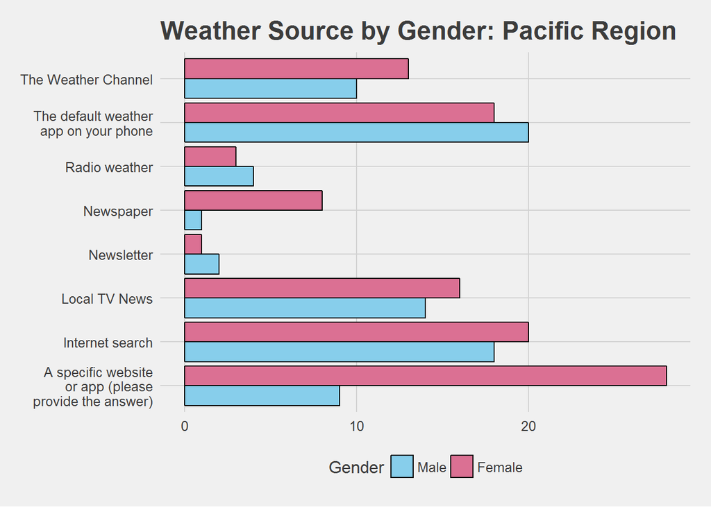